# Lab5

Andrew Bartnik

2023-05-10

We’ll start off today by loading the climbing incident data again.

```r
incidents_df<-read_csv("https://raw.githubusercontent.com/MaRo406/EDS-231-text-sentiment/main/data/climbing_reports_model_dat.csv")
```

First, let’s calculate the unigram probabilities – how often we see each word in this corpus.

```r
unigram_probs <- incidents_df |> unnest_tokens(word, Text) |> anti_join(stop_words, by = 'word') |> count(word, sort=T) |> mutate(p = n/sum(n))
unigram_probs
```

```
## # A tibble: 25,205 × 3
##    word         n       p
##    <chr>    <int>   <dbl>
##  1 rope      5129 0.00922
##  2 feet      5101 0.00917
##  3 climbing  4755 0.00855
##  4 route     4357 0.00783
##  5 climbers  3611 0.00649
##  6 climb     3209 0.00577
##  7 fall      3168 0.00569
##  8 climber   2964 0.00533
##  9 rescue    2928 0.00526
## 10 source    2867 0.00515
## # … with 25,195 more rows
```

OK, so that tells us the probability of each word.

Next, we need to know how often we find each word near each other word – the skipgram probabilities. In this case we’ll define the word context as a five-word window. We’ll slide that window across all of our text and record which words occur together within that window.

Now let’s write some code that adds an ngramID column that contains constituent information about each 5-gram we constructed by sliding our window.

```r
skipgrams <- incidents_df |> unnest_tokens(ngram, Text, token = "ngrams", n = 5) |> mutate(ngramID = row_number()) |> tidyr::unite(skipgramID, ID, ngramID) |> unnest_tokens(word, ngram) |> anti_join(stop_words, by = 'word')
```

Now we use widyr::pairwise_count() to sum the total # of occurences of each pair of words.

```r
#calculate probabilities
skipgram_probs <- skipgrams |> pairwise_count(word, skipgramID,diag = T, sort = T) |> mutate(p = n/sum(n))
```

The next step is to normalize these probabilities, that is, to calculate how often words occur together within a window, relative to their total occurrences in the data.

```r
normalized_prob <- skipgram_probs |> filter(n>20) |> rename(word1 = item1, word2=item2) |> left_join(unigram_probs |> select(word1 = word, p1 = p), by = 'word1') |>
  left_join(unigram_probs |> select(word2 = word, p2 = p), by = 'word2') |> mutate(p_together = p/p1/p2)

normalized_prob
```

```
## # A tibble: 31,240 × 7
##    word1    word2        n       p      p1      p2 p_together
##    <chr>    <chr>    <dbl>   <dbl>   <dbl>   <dbl>      <dbl>
##  1 rope     rope     25494 0.00340 0.00922 0.00922       40.0
##  2 feet     feet     25331 0.00338 0.00917 0.00917       40.2
##  3 climbing climbing 23320 0.00311 0.00855 0.00855       42.6
##  4 route    route    21696 0.00289 0.00783 0.00783       47.2
##  5 climbers climbers 17912 0.00239 0.00649 0.00649       56.7
##  6 climb    climb    15998 0.00213 0.00577 0.00577       64.2
##  7 fall     fall     15705 0.00210 0.00569 0.00569       64.6
##  8 climber  climber  14660 0.00196 0.00533 0.00533       68.9
##  9 rescue   rescue   14003 0.00187 0.00526 0.00526       67.5
## 10 rock     rock     13846 0.00185 0.00506 0.00506       72.3
## # … with 31,230 more rows
```

Now we have all the pieces to calculate the point-wise mutual information (PMI) measure. It’s the logarithm of the normalized probability of finding two words together. PMI tells us which words occur together more often than expected based on how often they occurred on their own.

Then we convert to a matrix so we can use matrix factorization and reduce the dimensionality of the data.

```r
pmi_matrix <- normalized_prob |> mutate(pmi = log10(p_together)) |> cast_sparse(word1, word2, pmi)
```

We do the singluar value decomposition with irlba::irlba(). It’s a “partial decomposition” as we are specifying a limited number of dimensions, in this case 100.

```r
pmi_matrix@x[is.na(pmi_matrix@x)]<0
```

```
## logical(0)
```

```r
pmi_svd <- irlba(pmi_matrix, 100, maxit = 500)
word_vectors <- pmi_svd$u

rownames(word_vectors) <- rownames(pmi_matrix)
```

These vectors in the “u” matrix are contain “left singular values”. They are orthogonal vectors that create a 100-dimensional semantic space where we can locate each word. The distance between words in this space gives an estimate of their semantic similarity.

Here’s a function written by Julia Silge for matching the most similar vectors to a given vector.

```r
search_synonyms <- function(word_vectors, selected_vector) {
dat <- word_vectors %*% selected_vector

similarities <- dat %>%
        tibble(token = rownames(dat), similarity = dat[,1])

similarities %>%
       arrange(-similarity) %>%
        select(c(2,3))
}
```

Let’s test it out!

```r
fall <- search_synonyms(word_vectors = word_vectors, word_vectors['fall',])
fall
```

```
## # A tibble: 9,104 × 2
##    token     similarity
##    <chr>          <dbl>
##  1 fall          0.119
##  2 rock          0.0524
##  3 rope          0.0403
##  4 line          0.0387
##  5 short         0.0374
##  6 ice           0.0354
##  7 accident      0.0347
##  8 foot          0.0345
##  9 avalanche     0.0326
## 10 coley         0.0324
## # … with 9,094 more rows
```

```r
slip <- search_synonyms(word_vectors = word_vectors, word_vectors['slip',])
slip
```

```
## # A tibble: 9,104 × 2
##    token     similarity
##    <chr>          <dbl>
##  1 fall         0.00604
##  2 rope         0.00535
##  3 meter        0.00440
##  4 lead         0.00349
##  5 short        0.00266
##  6 gentzel      0.00215
##  7 coley        0.00214
##  8 line         0.00214
##  9 operation    0.00210
## 10 dome         0.00203
## # … with 9,094 more rows
```

```r
ice <- search_synonyms(word_vectors = word_vectors, word_vectors['ice',])
ice
```

```
## # A tibble: 9,104 × 2
##    token    similarity
##    <chr>         <dbl>
##  1 ice          0.307
##  2 crampons     0.143
##  3 axe          0.0932
##  4 axes         0.0905
##  5 ax           0.0882
##  6 snow         0.0831
##  7 boots        0.0753
##  8 tools        0.0711
##  9 wearing      0.0710
## 10 screws       0.0680
## # … with 9,094 more rows
```

Here’s a plot for visualizing the most similar words to a given target word.

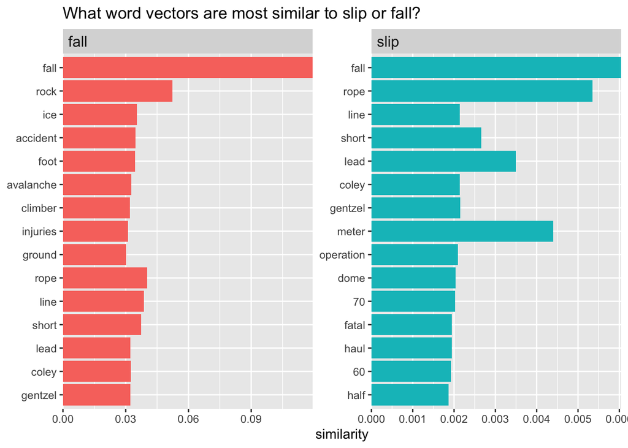

```r
slip %>%
    mutate(selected = "slip") %>%
    bind_rows(fall %>%
                  mutate(selected = "fall")) %>%
    group_by(selected) %>%
    top_n(15, similarity) %>%
    ungroup %>%
    mutate(token = reorder(token, similarity)) %>%
    ggplot(aes(token, similarity, fill = selected)) +
    geom_col(show.legend = FALSE) +
    facet_wrap(~selected, scales = "free") +
    coord_flip() +
    theme(strip.text=element_text(hjust=0, size=12)) +
    scale_y_continuous(expand = c(0,0)) +
    labs(x = NULL, title = "What word vectors are most similar to slip or fall?")
```

One of the cool things about representing words as numerical vectors is that we can use math on those numbers that has some semantic meaning.

```r
snow_danger <- word_vectors["snow",] + word_vectors["danger",]
search_synonyms(word_vectors, snow_danger)
```

```
## # A tibble: 9,104 × 2
##    token      similarity
##    <chr>           <dbl>
##  1 snow           0.396
##  2 avalanche      0.131
##  3 conditions     0.0918
##  4 soft           0.0806
##  5 wet            0.0783
##  6 ice            0.0769
##  7 icy            0.0735
##  8 slope          0.0703
##  9 fresh          0.0604
## 10 blindness      0.0596
## # … with 9,094 more rows
```

```r
no_snow_danger <- word_vectors["danger",] - word_vectors["snow",]
search_synonyms(word_vectors, no_snow_danger)
```

```
## # A tibble: 9,104 × 2
##    token     similarity
##    <chr>          <dbl>
##  1 avalanche     0.0882
##  2 danger        0.0547
##  3 rockfall      0.0540
##  4 gulch         0.0534
##  5 class         0.0507
##  6 hazard        0.0403
##  7 hazards       0.0394
##  8 occurred      0.0376
##  9 potential     0.0373
## 10 mph           0.0361
## # … with 9,094 more rows
```

### Assignment

#### Train Your Own Embeddings

#1.  
Using the data from your Nexis Uni query from Week 2, create a set of word embeddings. To do this, you’ll essentially need to recreate the steps in today’s example down through the chunk named “pmi”.

```r
pre_files <- list.files(pattern = ".docx",
                        path = "~/Desktop/MEDS/Spring/text/text_analysis/lab2/files2",
                       full.names = TRUE,
                       recursive = TRUE,
                       ignore.case = TRUE)


pre_dat <- lnt_read(pre_files)
```

```
## Creating LNToutput from 101 files...
```

[output not shown]

[output not shown]

[output not shown]

[output not shown]

[output not shown]

[output not shown]

[output not shown]

[output not shown]

[output not shown]

[output not shown]

[output not shown]

[output not shown]

[output not shown]

```
## Elapsed time: 0.31 secs
```

```r
meta <- pre_dat@meta
articles <- pre_dat@articles
paragraphs <- pre_dat@paragraphs

data <- tibble(Date = meta$Date, Headline = meta$Headline, id = pre_dat@articles$ID, text = pre_dat@articles$Article)
```

```r
unigram_probs_lexis <- data |> unnest_tokens(word, text) |> anti_join(stop_words, by = 'word') |> count(word, sort=T) |> mutate(p = n/sum(n))
unigram_probs_lexis
```

```
## # A tibble: 6,528 × 3
##    word              n       p
##    <chr>         <int>   <dbl>
##  1 biodiversity    866 0.0292
##  2 species         238 0.00801
##  3 climate         173 0.00582
##  4 conservation    162 0.00545
##  5 diversity       146 0.00491
##  6 nature          145 0.00488
##  7 environment     141 0.00475
##  8 water           137 0.00461
##  9 environmental   128 0.00431
## 10 natural         128 0.00431
## # … with 6,518 more rows
```

```r
lexis_skipgrams <- data |> unnest_tokens(ngram, text, token = "ngrams", n = 5) |> mutate(ngramID = row_number()) |> tidyr::unite(skipgramID, id, ngramID) |> unnest_tokens(word, ngram) |> anti_join(stop_words, by = 'word')
```

```r
#calculate probabilities
lexis_skipgram_probs <- lexis_skipgrams |> pairwise_count(word, skipgramID,diag = T, sort = T) |> mutate(p = n/sum(n))
```

```r
norm_prob_lexis <- lexis_skipgram_probs |>
  filter(n>20) |>
  rename(word1 = item1, word2=item2) |>
  left_join(unigram_probs_lexis |> select(word1 = word, p1 = p), by = 'word1') |>
  left_join(unigram_probs_lexis |> select(word2 = word, p2 = p), by = 'word2') |> mutate(p_together = p/p1/p2)
```

```r
pmi_matrix_lexis <- norm_prob_lexis |> mutate(pmi = log10(p_together)) |> cast_sparse(word1, word2, pmi)
pmi_matrix_lexis@x[is.na(pmi_matrix_lexis@x)]<0
```

```
## logical(0)
```

```r
pmi_svd <- irlba(pmi_matrix_lexis, 100, maxit = 500)
word_vectors_lexis <- pmi_svd$u

rownames(word_vectors_lexis) <- rownames(pmi_matrix_lexis)
```

#2.  
Think of 3-5 key words in your data set. Calculate and plot the 10 most semantically similar words for each of them. Identify and interpret any interesting or surprising results.

**biodiversity, climate, species, nature, and change**

```r
biodiversity <- search_synonyms(word_vectors = word_vectors_lexis, word_vectors_lexis['biodiversity',])
biodiversity
```

```
## # A tibble: 1,395 × 2
##    token        similarity
##    <chr>             <dbl>
##  1 biodiversity     0.357
##  2 hotspots         0.152
##  3 threats          0.127
##  4 council          0.111
##  5 view             0.102
##  6 conserve         0.0981
##  7 assessment       0.0943
##  8 funds            0.0926
##  9 framework        0.0926
## 10 board            0.0919
## # … with 1,385 more rows
```

```r
climate <- search_synonyms(word_vectors = word_vectors_lexis, word_vectors_lexis['climate',])
climate
```

```
## # A tibble: 1,395 × 2
##    token        similarity
##    <chr>             <dbl>
##  1 climate         0.396
##  2 nexus           0.374
##  3 crisis          0.229
##  4 change          0.206
##  5 environment     0.0614
##  6 minister        0.0169
##  7 protecting      0.0125
##  8 biodiversity    0.00732
##  9 local           0.00278
## 10 fund            0.00187
## # … with 1,385 more rows
```

```r
species <- search_synonyms(word_vectors = word_vectors_lexis, word_vectors_lexis["species",])
species
```

```
## # A tibble: 1,395 × 2
##    token      similarity
##    <chr>           <dbl>
##  1 species        0.382
##  2 keystone       0.238
##  3 invasive       0.227
##  4 richness       0.198
##  5 animal         0.127
##  6 endangered     0.125
##  7 threatened     0.125
##  8 plant          0.123
##  9 extinction     0.0867
## 10 wild           0.0795
## # … with 1,385 more rows
```

```r
nature <- search_synonyms(word_vectors = word_vectors_lexis, word_vectors_lexis['nature',])
nature
```

```
## # A tibble: 1,395 × 2
##    token         similarity
##    <chr>              <dbl>
##  1 nature            0.297
##  2 positive          0.248
##  3 related           0.235
##  4 based             0.150
##  5 issues            0.133
##  6 impact            0.126
##  7 risks             0.124
##  8 opportunities     0.0857
##  9 conservation      0.0206
## 10 systems           0.0110
## # … with 1,385 more rows
```

```r
change <- search_synonyms(word_vectors = word_vectors_lexis, word_vectors_lexis["change",])
change
```

```
## # A tibble: 1,395 × 2
##    token         similarity
##    <chr>              <dbl>
##  1 climate          0.206
##  2 nexus            0.198
##  3 crisis           0.114
##  4 change           0.110
##  5 environment      0.0257
##  6 fund             0.00557
##  7 index            0.00372
##  8 based            0.00287
##  9 nature           0.00275
## 10 international    0.00256
## # … with 1,385 more rows
```

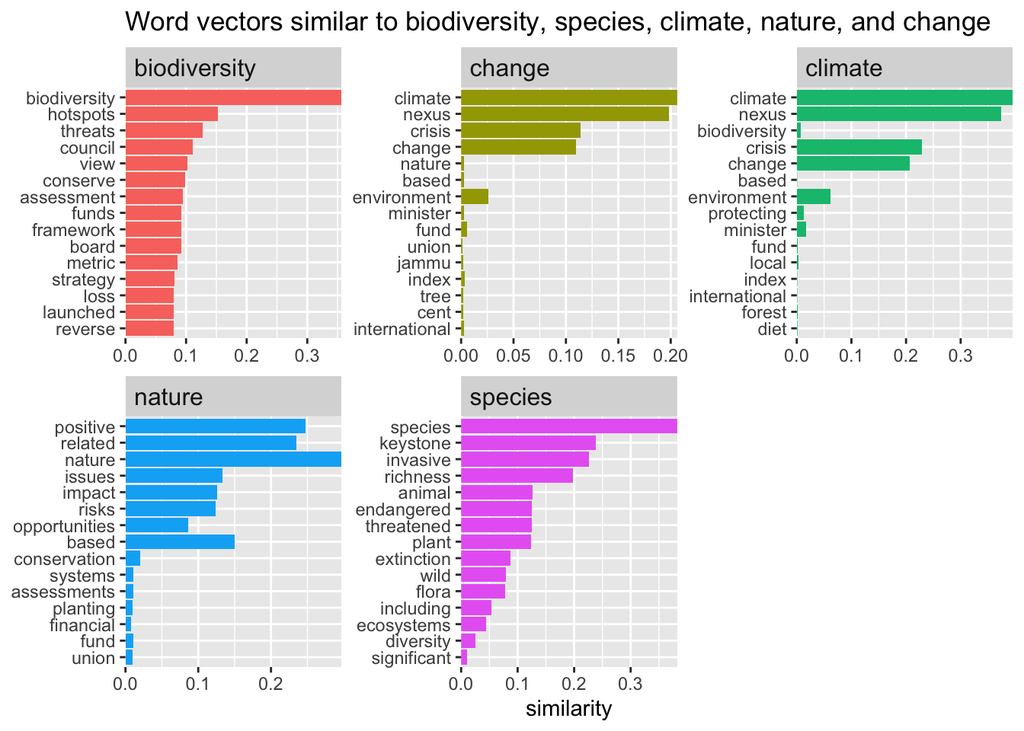

```r
biodiversity %>%
    mutate(selected = "biodiversity") %>%
    bind_rows(species %>%
                  mutate(selected = "species"),
              climate |> mutate(selected = "climate"),
              nature |> mutate(selected = "nature"),
              change |> mutate(selected = "change")) %>%
    group_by(selected) %>%
    top_n(15, similarity) %>%
    ungroup %>%
    mutate(token = reorder(token, similarity)) %>%
    ggplot(aes(token, similarity, fill = selected)) +
    geom_col(show.legend = FALSE) +
    facet_wrap(~selected, scales = "free") +
    coord_flip() +
    theme(strip.text=element_text(hjust=0, size=12)) +
    scale_y_continuous(expand = c(0,0)) +
    labs(x = NULL, title = "Word vectors similar to biodiversity, species, climate, nature, and change ")
```

# 3.

Assemble 3 word math equations that you think could be useful or interesting for exploring the meaning of key words or ideas in your data set. **Climate crisis, species not extinct, biodiversity hotspots**

```r
climate_crisis <- word_vectors_lexis["climate",] + word_vectors_lexis["crisis",]
search_synonyms(word_vectors_lexis, climate_crisis)
```

```
## # A tibble: 1,395 × 2
##    token        similarity
##    <chr>             <dbl>
##  1 climate          0.624
##  2 nexus            0.588
##  3 crisis           0.379
##  4 change           0.320
##  5 biodiversity     0.0812
##  6 environment      0.0763
##  7 hotspots         0.0309
##  8 threats          0.0258
##  9 council          0.0226
## 10 view             0.0207
## # … with 1,385 more rows
```

```r
no_extinction <- word_vectors_lexis["extinction",] - word_vectors_lexis["species",]
search_synonyms(word_vectors_lexis, no_extinction)
```

```
## # A tibble: 1,395 × 2
##    token      similarity
##    <chr>           <dbl>
##  1 threatened    0.195
##  2 including     0.162
##  3 extinction    0.130
##  4 habitat       0.0878
##  5 eritrea       0.0233
##  6 progress      0.00533
##  7 foods         0.00358
##  8 fund          0.00290
##  9 resources     0.00241
## 10 index         0.00182
## # … with 1,385 more rows
```

```r
biodiversity_hotspot <- word_vectors_lexis["biodiversity",] + word_vectors_lexis["hotspots",]
search_synonyms(word_vectors_lexis, biodiversity_hotspot)
```

```
## # A tibble: 1,395 × 2
##    token        similarity
##    <chr>             <dbl>
##  1 biodiversity      0.509
##  2 hotspots          0.240
##  3 threats           0.199
##  4 council           0.169
##  5 view              0.158
##  6 conserve          0.152
##  7 assessment        0.146
##  8 framework         0.145
##  9 board             0.142
## 10 funds             0.141
## # … with 1,385 more rows
```

#4.  
Following the example in the SMLTR text (section 5.4), create a set of 100-dimensional GloVe word embeddings. These embeddings were trained by researchers at Stanford on 6 billion tokens from Wikipedia entries.

```r
glove6b <- read_csv("glove6b.csv")
```

```
## ──────────────────────────────────────────────────────── Delimiter: "," chr
## (1): token dbl (101): ...1, d1, d2, d3, d4, d5, d6, d7, d8, d9, d10, d11, d12,
## d13, d14...
```

```r
# Convert the data frame to a matrix
glove6b_matrix <- as.matrix(glove6b[,-(1:2)])

# Set the row names of the matrix to be the token column from the data frame
rownames(glove6b_matrix) <- glove6b$token
```

#### Pretrained Embeddings

#5.  
Test them out with the cannonical word math equation on the GloVe embeddings: “berlin” - “germany” + “france” = ?

```r
glove_math <- glove6b_matrix["berlin",] - glove6b_matrix["germany",] + glove6b_matrix["france",]
search_synonyms(glove6b_matrix, glove_math)
```

```
## # A tibble: 400,000 × 2
##    token    similarity
##    <chr>         <dbl>
##  1 paris          34.4
##  2 france         31.5
##  3 french         28.0
##  4 de             28.0
##  5 le             26.6
##  6 london         25.4
##  7 la             24.3
##  8 brussels       23.3
##  9 berlin         23.3
## 10 lyon           22.2
## # … with 399,990 more rows
```

#6.  
Recreate parts 2 and 3 above using the the GloVe embeddings in place of the ones you trained. How do they compare? What are the implications for applications of these embeddings?

**The synonym similarities for the GloVe embeddings are much higher than for the articles I selected. The synonyms chosen are also much more pertinent to each word. This is expected since the GloVe embeddings are much more comprehensive.**

```r
biodiversity <- search_synonyms(word_vectors = glove6b_matrix, glove6b_matrix['biodiversity',])
biodiversity
```

```
## # A tibble: 400,000 × 2
##    token        similarity
##    <chr>             <dbl>
##  1 biodiversity       32.0
##  2 ecosystems         25.4
##  3 habitat            25.2
##  4 habitats           24.5
##  5 conservation       24.4
##  6 ecosystem          24.0
##  7 wildlife           23.3
##  8 species            23.1
##  9 wetlands           23.0
## 10 ecological         22.9
## # … with 399,990 more rows
```

```r
climate <- search_synonyms(word_vectors = glove6b_matrix, glove6b_matrix['climate',])
climate
```

```
## # A tibble: 400,000 × 2
##    token         similarity
##    <chr>              <dbl>
##  1 climate             40.4
##  2 warming             30.0
##  3 environment         28.1
##  4 economic            27.5
##  5 köppen              27.0
##  6 global              26.7
##  7 environmental       26.0
##  8 weather             25.4
##  9 conditions          25.3
## 10 emissions           25.1
## # … with 399,990 more rows
```

```r
species <- search_synonyms(word_vectors = glove6b_matrix, glove6b_matrix["species",])
species
```

```
## # A tibble: 400,000 × 2
##    token      similarity
##    <chr>           <dbl>
##  1 species          55.6
##  2 genus            42.6
##  3 subspecies       36.8
##  4 birds            35.3
##  5 endemic          34.0
##  6 habitat          33.8
##  7 habitats         33.8
##  8 endangered       33.2
##  9 mammals          31.7
## 10 fish             31.1
## # … with 399,990 more rows
```

```r
nature <- search_synonyms(word_vectors = glove6b_matrix, glove6b_matrix['nature',])
nature
```

```
## # A tibble: 400,000 × 2
##    token      similarity
##    <chr>           <dbl>
##  1 nature           26.9
##  2 natural          21.1
##  3 human            20.9
##  4 life             20.5
##  5 physical         20.1
##  6 that             19.7
##  7 what             19.6
##  8 behavior         19.6
##  9 animals          19.5
## 10 historical       19.4
## # … with 399,990 more rows
```

```r
change <- search_synonyms(word_vectors = glove6b_matrix, glove6b_matrix["change",])
change
```

```
## # A tibble: 400,000 × 2
##    token    similarity
##    <chr>         <dbl>
##  1 change         28.7
##  2 changes        26.7
##  3 we             26.5
##  4 if             24.9
##  5 would          24.8
##  6 this           24.7
##  7 economic       24.7
##  8 not            24.4
##  9 that           24.3
## 10 to             24.2
## # … with 399,990 more rows
```

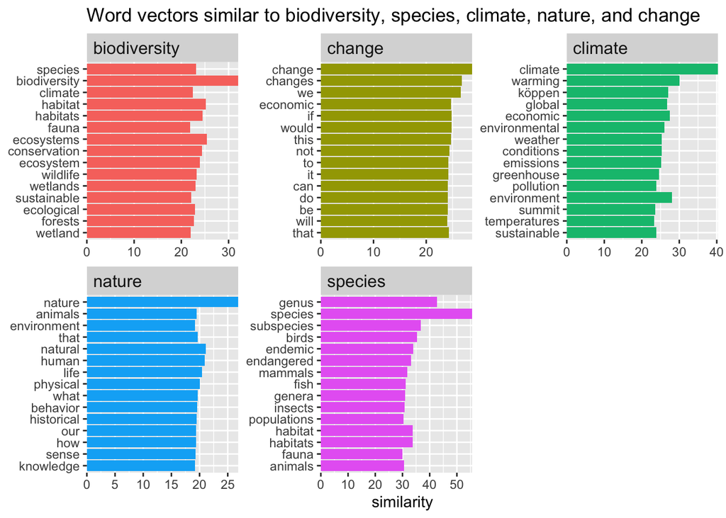

```r
biodiversity %>%
    mutate(selected = "biodiversity") %>%
    bind_rows(species %>%
                  mutate(selected = "species"),
              climate |> mutate(selected = "climate"),
              nature |> mutate(selected = "nature"),
              change |> mutate(selected = "change")) %>%
    group_by(selected) %>%
    top_n(15, similarity) %>%
    ungroup %>%
    mutate(token = reorder(token, similarity)) %>%
    ggplot(aes(token, similarity, fill = selected)) +
    geom_col(show.legend = FALSE) +
    facet_wrap(~selected, scales = "free") +
    coord_flip() +
    theme(strip.text=element_text(hjust=0, size=12)) +
    scale_y_continuous(expand = c(0,0)) +
    labs(x = NULL, title = "Word vectors similar to biodiversity, species, climate, nature, and change ")
```

```r
climate_crisis <- glove6b_matrix["climate",] + glove6b_matrix["crisis",]
search_synonyms(glove6b_matrix, climate_crisis)
```

```
## # A tibble: 400,000 × 2
##    token       similarity
##    <chr>            <dbl>
##  1 climate           61.4
##  2 crisis            60.9
##  3 economic          60.0
##  4 global            53.3
##  5 economy           50.4
##  6 warming           47.6
##  7 situation         46.1
##  8 summit            45.6
##  9 countries         45.4
## 10 environment       45.2
## # … with 399,990 more rows
```

```r
no_extinction <- glove6b_matrix["extinction",] - glove6b_matrix["species",]
search_synonyms(glove6b_matrix, no_extinction)
```

```
## # A tibble: 400,000 × 2
##    token              similarity
##    <chr>                   <dbl>
##  1 non-families             16.1
##  2 iyanla                   14.9
##  3 (813)                    14.8
##  4 meh                      14.5
##  5 soundview                14.2
##  6 blogs.tampabay.com       14.0
##  7 naroff                   13.6
##  8 bihn                     13.5
##  9 smallcap                 13.3
## 10 mahagonny                13.1
## # … with 399,990 more rows
```

```r
biodiversity_hotspot <- glove6b_matrix["biodiversity",] + glove6b_matrix["hotspots",]
search_synonyms(glove6b_matrix, biodiversity_hotspot)
```

```
## # A tibble: 400,000 × 2
##    token           similarity
##    <chr>                <dbl>
##  1 biodiversity          43.9
##  2 hotspots              36.4
##  3 ecosystems            34.9
##  4 habitats              34.3
##  5 desertification       32.6
##  6 climate               31.0
##  7 habitat               30.6
##  8 wildlife              30.5
##  9 ecosystem             30.4
## 10 wetlands              30.3
## # … with 399,990 more rows
```